# Faza I

Tomasz Bielak, Paweł Górniak

23 października 2016

# Implementacja stada

Tworzymy funkcję tworzącą dwie globalne zmienne opisujące początkową populacja zwierząt w stadzie: **nazwa** - wektor nazw zwierząt **stado** - data frame z nazwami i liczebnościami

Stan stada na początku gry: 60 królików, 24 owce, 20 świń, 12 krów, 6 koni, 4 małe psy, 2 duże psy.

```r
f.inicjalizacja_stada<-function(){
  nazwy<<-c("Królik","Owca","Świnia","Krowa","Koń","Mały pies","Duży pies")
  liczebnosc<-c(60,24,20,12,6,4,2)
  stado<<-data.frame(nazwy,liczebnosc)
}
```

Uruchamiamy funkcję…

```r
f.inicjalizacja_stada()
```

… i sprawdzamy jak wyglądają utworzone przez funkcję zmienne:

```r
print(nazwy)
```

```
## [1] "Królik"    "Owca"      "Świnia"    "Krowa"     "Koń"       "Mały pies"
## [7] "Duży pies"
```

```r
print(stado)
```

```
##       nazwy liczebnosc
## 1    Królik         60
## 2      Owca         24
## 3    Świnia         20
## 4     Krowa         12
## 5       Koń          6
## 6 Mały pies          4
## 7 Duży pies          2
```

# Implementacja kostek do gry

Tworzymy funkcję tworzącą dwie globalne zmienne z listą wszystkich zwierząt występujących w świecie Super Farmer (łącznie z Wilkiem i Lisem) oraz wagami definiującymi prawdopodobieństwa wyrzucenia każdego z pól w dalszej części kodu:

```r
f.inicjalizacja_kostek<-function(){
kostka1<<-data.frame(nazwy=c(nazwy,"Wilk","Lis"),weight=c(6,3,1,1,0,0,0,1,0))
kostka2<<-data.frame(nazwy=c(nazwy,"Wilk","Lis"),weight=c(6,2,2,0,1,0,0,0,1))
}
```

Uruchamiamy funkcję…

```r
f.inicjalizacja_kostek()
```

… i sprawdzamy jak wyglądają utworzone przez funkcję zmienne:

```r
print(kostka1)
```

```
##       nazwy weight
## 1    Królik      6
## 2      Owca      3
## 3    Świnia      1
## 4     Krowa      1
## 5       Koń      0
## 6 Mały pies      0
## 7 Duży pies      0
## 8      Wilk      1
## 9       Lis      0
```

```r
print(kostka2)
```

```
##       nazwy weight
## 1    Królik      6
## 2      Owca      2
## 3    Świnia      2
## 4     Krowa      0
## 5       Koń      1
## 6 Mały pies      0
## 7 Duży pies      0
## 8      Wilk      0
## 9       Lis      1
```

# Implementacja tabeli wymian

Tabelę wymian implementujemy w formie macierzy 7x7, w której występują wszystkie zwierzęta niebędące drapieżnikami atakującymi stado.

```r
f.inicjalizacja_tabeli_wymian<-function(){
wymiany<<-matrix(
  c(c(0 ,1/6,0  ,0  ,0  ,0  ,0  ),
    c(6 ,0  ,1/2,0  ,0  ,1  ,0  ),
    c(0 ,2  ,0  ,1/3,0  ,0  ,0  ),
    c(0 ,0  ,3  ,0  ,1/2,0  ,1  ),
    c(0 ,0  ,0  ,2  ,0  ,0  ,0  ),
    c(0 ,1  ,0  ,0  ,0  ,0  ,0  ),
    c(0 ,0  ,0  ,1  ,0  ,0  ,0  )
  ),ncol=7,byrow=TRUE)
rownames(wymiany)<<-nazwy
colnames(wymiany)<<-nazwy
}
```

Uruchamiamy funkcję…

```r
f.inicjalizacja_tabeli_wymian()
```

… i sprawdzamy jak wygląda utworzona macierz wymian. Każdy wiersz reprezentuje zwierze które **otrzymujemy w wyniku wymiany**, każda kolumna reprezentuje zwierze ktore **oddajemy w celu wymiany** zaś wartości tabeli oznaczają ile sztuk zwierzaka z kolumny trzeba oddać, aby otrzymać **jednego** zwierza z wiersza. Ważne jest to, że wartości mogą być niecałkowite, bo wartości mówią ile sztuk zwierza z kolumny jest równoważne jednemu zwierzowi z wiersza.

```r
print(wymiany)
```

```
##           Królik      Owca Świnia     Krowa Koń Mały pies Duży pies
## Królik         0 0.1666667    0.0 0.0000000 0.0         0         0
## Owca           6 0.0000000    0.5 0.0000000 0.0         1         0
## Świnia         0 2.0000000    0.0 0.3333333 0.0         0         0
## Krowa          0 0.0000000    3.0 0.0000000 0.5         0         1
## Koń            0 0.0000000    0.0 2.0000000 0.0         0         0
## Mały pies      0 1.0000000    0.0 0.0000000 0.0         0         0
## Duży pies      0 0.0000000    0.0 1.0000000 0.0         0         0
```

# Implementacja stad graczy

Tworzymy funkcję, która w zależności od zdefiniowanej liczby graczy tworzy globalne zmienne opisujące liczebność sztuk i par zwierzaków w stadzie. Funkcja troche na wyrost, stworzona zanim zorientowaliśmy się, że gracz ma być tylko jeden:

```r
f.inicjalizacja_graczy<-function(players=1){
  for(i in 1:players){
    assign(paste('gracz', i, sep=''), data.frame(nazwy,liczebnosc=c(0,0,0,0,0,0,0),pary=c(0,0,0,0,0,0,0)),envir = .GlobalEnv)
  }
}
```

Uruchamiamy funkcję…

```r
f.inicjalizacja_graczy(players=1)
```

… i sprawdzamy czy gracz 1 ma gdzie trzymać zwierzęta:

```r
print(gracz1)
```

```
##       nazwy liczebnosc pary
## 1    Królik          0    0
## 2      Owca          0    0
## 3    Świnia          0    0
## 4     Krowa          0    0
## 5       Koń          0    0
## 6 Mały pies          0    0
## 7 Duży pies          0    0
```

# Implementacja losowania kostek

Tworzymy funkcję, która będzie zwracała dwuelementowy wektor z wynikiem losowania na pierwszej kostce i na drugiej kostce. Losowanie implementujemy za pomocą funkcji **sample** podając jej wektor nazw (parametr 1) jako zbiór z którego losujemy 1 element (parametr 2), ze zwracaniem (parametr 3) określając wagi definiujące prawdopodobieństwo wylosowania zwierzaka (parametr 4).

```r
f.losowanie<-function(){
wynik<<-c(sample(as.character(kostka1[[1]]),1,TRUE,prob=kostka1[[2]]),sample(as.character(kostka2[[1]]),1,TRUE,prob=kostka2[[2]]))
return(wynik)
}
```

Przy każdym uruchomieniu kostki otrzymujemy inne wyniki:

```r
f.losowanie()
```

```
## [1] "Owca"   "Świnia"
```

```r
f.losowanie()
```

```
## [1] "Krowa"  "Królik"
```

```r
f.losowanie()
```

```
## [1] "Krowa" "Owca"
```

```r
f.losowanie()
```

```
## [1] "Królik" "Owca"
```

# Implementacja strat po wylosowaniu drapieżników

Funkcja zwraca wektor ze zwierzakami, które podlegają zerowaniu przy wylosowaniu danego drapieżnika:

```r
#definicja w formie listy zwierząt podlegających zerowaniu
f.drapiezniki<-function(co_wylosowalem){
  if(co_wylosowalem=="Wilk"){
    return(c("Królik","Owca","Świnia","Krowa","Duży pies"))
  }else{
   return(c("Królik"))
  }
}
```

Uruchamiamy funkcję dla obu drapieżników:

```r
f.drapiezniki("Lis")
```

```
## [1] "Królik"
```

```r
f.drapiezniki("Wilk")
```

```
## [1] "Królik"    "Owca"      "Świnia"    "Krowa"     "Duży pies"
```

# Transfery między stadem a graczem i na odwrót

Funkcja ta bierze jako argumety: nazwe zwierzaka, który jest przedmiotem wymiany, postulowaną ilość oraz kierunek wymiany (Gracz/Stado):

```r
f.transfer<-function(zwierze="Królik",ilosc,kierunek){

  #określam który wiersz w data frame to zwierze
  i=which(gracz1[,1]==zwierze)

  #sprawdzam ile zwierzaka ma gracz
  aktualny_stan_zwierzaka<-gracz1[i,2]

  #sprawdzam ile zwierzaka jest w stadzie
  aktualny_stan_zwierzaka_w_stadzie<-stado[i,2]

  if(kierunek=="Gracz"){

    #określam ile zwierzaka moge przenieść ze stada
    transfer<-min(ilosc,aktualny_stan_zwierzaka_w_stadzie)

    #aktualizuję stan zwierząt gracza
    gracz1[i,2]<<-aktualny_stan_zwierzaka+transfer

    #aktualizuję stan par zwierząt stada
    gracz1[,3]<<-floor(gracz1[,2]/2)

    #aktualizuję stan stada
    stado[i,2]<<-aktualny_stan_zwierzaka_w_stadzie-transfer
  }else{

    #określam ile zwierzaka moge przenieść ze stada
    transfer<-min(ilosc,aktualny_stan_zwierzaka)

    #aktualizuję stan stada
    stado[i,2]<<-aktualny_stan_zwierzaka_w_stadzie+transfer

    #aktualizuję stan zwierząt gracza
    gracz1[i,2]<<-aktualny_stan_zwierzaka-transfer

    #aktualizuję stan par zwierząt stada
    gracz1[,3]<<-floor(gracz1[,2]/2)

  }

}
```

# Zmiany stanu stada gracza po losowaniu

Efekt rzutu kostką na stan stada losującego gracza. Dokładne działanie kodu opisane w komentarzach

```r
f.update_stanu_stada<-function(wynik){

  if((wynik[1]!="Wilk") & (wynik[1]!="Lis") & (wynik[2]!="Wilk") & (wynik[2]!="Lis")){
      if (wynik[1]==wynik[2]){

        #Dodanie jednego zwierzaka dla którego wystąpił remis
        f.transfer(zwierze=wynik[1],ilosc=1,kierunek="Gracz")

      }else{

        #Dodanie zwierzaków z pierwszego losowania w liczbie równej liczbie par
        ile_par_1=gracz1[gracz1[,1]==wynik[1],3]
        f.transfer(wynik[1],ile_par_1,"Gracz")

        #Dodanie zwierzaków z drugiego losowania w liczbie równej liczbie par
        ile_par_2=gracz1[gracz1[,1]==wynik[2],3]
        f.transfer(wynik[2],ile_par_2,"Gracz")

        #Update kolumny z liczbą par zwierzaków gracza
        gracz1[,3]<<-round(gracz1[,2]/2,0)

      }
  }

  #Zerowanie zwierząt gdy wylosujemy wilka
  if(wynik[1]=="Wilk" | wynik[2]=="Wilk"){
    for(i in 1:nrow(gracz1)) {
      if(gracz1[7,1]==0){

        #Sytuacja gdy nie mamy dużego psa
        if(gracz1[i,1] %in% f.drapiezniki("Wilk")){
          stado[i,2]<<-stado[i,2]+gracz1[i,2]
          gracz1[i,2]<<-0
          gracz1[i,3]<<-0
          gracz1[,3]<<-round(gracz1[,2]/2,0)
        }

      }else{

        #Sytuacja gdy mamy dużego psa
        stado[7,2]<<-stado[7,2]+gracz1[7,2]
        gracz1[7,2]<<-0
        gracz1[,3]<<-round(gracz1[,2]/2,0)

      }
    }
  }

  #Zerowanie zwierząt gdy wylosujemy lisa
  if(wynik[1]=="Lis" | wynik[2]=="Lis"){
    for(i in 1:nrow(gracz1)) {
      if(gracz1[6,1]==0){

        #Sytuacja gdy nie mamy małego psa
        if(gracz1[i,1] %in% f.drapiezniki("Lis")){
          stado[i,2]<<-stado[i,2]+gracz1[i,2]
          gracz1[i,2]<<-0
          gracz1[i,3]<<-0
          gracz1[,3]<<-round(gracz1[,2]/2,0)
        }

      }else{

        #Sytuacja gdy mamy małego psa
        stado[6,2]<<-stado[6,2]+gracz1[6,2]
        gracz1[6,2]<<-0
        gracz1[,3]<<-round(gracz1[,2]/2,0)

      }
    }
  }

}
```

# Wymiany zwierząt według strategii gracza

```r
f.zastosuj_strategie_losowa<-function(){

  #Budujemy macierz inykatorów, które wskażą które wymiany są dopuszczalne
  wymiany_dopuszczalne<<-wymiany
  for(i in 1:nrow(wymiany)){
    for(j in 1:ncol(wymiany)){
      if(wymiany[i,j]==0){
        wymiany_dopuszczalne[i,j]<-0
      }else{
        zwierze_po<-rownames(wymiany)[i]
        zwierze_przed<-colnames(wymiany)[j]
        if((wymiany[i,j]==floor(wymiany[i,j])) & (gracz1[j,2]>=wymiany[i,j]) & stado[i,2]>=1){
          wymiany_dopuszczalne[i,j]<-1
        }else if((wymiany[i,j]!=floor(wymiany[i,j])) & (gracz1[j,2]>=1) & stado[i,2]>=(wymiany[i,j])^(-1)){
          wymiany_dopuszczalne[i,j]<-1
        }else{
          wymiany_dopuszczalne[i,j]<-0
        }
      }
    }
  }

  if(any(wymiany_dopuszczalne!=0)){


#Tabela przeliczników wymian w formie listy + info czy dopuszczalne
  lista_przelicznikow<<-data.frame(
     expand.grid(co_dostaje=rownames(wymiany),ile_dostaje=1,co_oddaje=colnames(wymiany)),
     ile_oddaje=as.vector(wymiany),czy_dopuszczalne=as.vector(wymiany_dopuszczalne),ile_mam=as.vector(tcrossprod(rep(1,7),gracz1[,2]))
  )

#Lista przeliczników zostaje przekształcona tak, aby usunąć ułamki
lista_przelicznikow$ile_dostaje<-ifelse(floor(lista_przelicznikow$ile_oddaje)==0 & lista_przelicznikow$ile_oddaje!=0,lista_przelicznikow$ile_dostaje/lista_przelicznikow$ile_oddaje,lista_przelicznikow$ile_dostaje)
lista_przelicznikow$ile_oddaje<-ifelse(floor(lista_przelicznikow$ile_oddaje)==0 & lista_przelicznikow$ile_oddaje!=0,1,lista_przelicznikow$ile_oddaje)

if(nrow(lista_przelicznikow[lista_przelicznikow$czy_dopuszczalne==1 & lista_przelicznikow$ile_mam!=0,])!=0){
mozliwosci<<-lista_przelicznikow[lista_przelicznikow$czy_dopuszczalne==1 & lista_przelicznikow$ile_mam!=0,]
}else{
mozliwosci<<-lista_przelicznikow[lista_przelicznikow$czy_dopuszczalne==1,]
}
#Reguła wyboru spośród dopuszczalnych możliwości
wybor<<-mozliwosci[sample(nrow(mozliwosci), 1), ]

f.transfer(zwierze=wybor[1,1],ilosc=wybor[1,2],kierunek="Gracz")
f.transfer(zwierze=wybor[1,3],ilosc=wybor[1,4],kierunek="Stado")
}

}
```

# Analiza osiągniętych wyników

Statystyki opisowe dla zmiennej czasu gry, wykres pojedynczych wyników gry oraz wykres średniej po n partiach

```r
f.statystyki<-function(historia){
summary(historia)
plot(historia, main="Wyniki poszczególnych symulacji",
    xlab="Liczba symulacji (n)", ylab="Liczba rund w grze")
plot(cumsum(historia) / seq_along(historia),main="Średnia z n symulacji",
    xlab="Liczba symulacji (n)", ylab="Liczba rund w grze ")
}
```

# Symulacja gry

Liczba symulacji to jedyny parametr, domyślnie wartość 100.

```r
f.symuluj<-function(powt=100){
  historia<<-numeric()
  f.inicjalizacja_stada()
  f.inicjalizacja_kostek()
  f.inicjalizacja_tabeli_wymian()
  #100 symulacji
  for(i in 1:powt){

    #zerujemy stan gry
    f.inicjalizacja_stada()
    f.inicjalizacja_graczy()

    #zerujemy licznik liczby rund
    runda<-0

    repeat{

      #inkrementujemy licznik rund
      runda<-runda+1

      #losujemy kostkami i uaktualniamy stan stad
      f.update_stanu_stada(f.losowanie())

      #dokonujemy wymian według strategii
      f.zastosuj_strategie_losowa()

      #sprawdzamy czy warunek stopu spełniony
      if(all(gracz1[,2]>=c(1,1,1,1,1,1,1))){

        #zapisujemy wynik partii
        historia<<-c(historia,runda)

        #przerywamy pętlę
        break
      }
    }
  }

  #statystyki gier
  return(historia)
}
```

Uruchamiamy symulację

```r
historia<-f.symuluj(10000)
```

Statystyki opisowe

```r
summary(historia)
```

```
##    Min. 1st Qu.  Median    Mean 3rd Qu.    Max.
##    37.0    87.0   103.0   105.7   121.0   281.0
```

Kilka wykresów

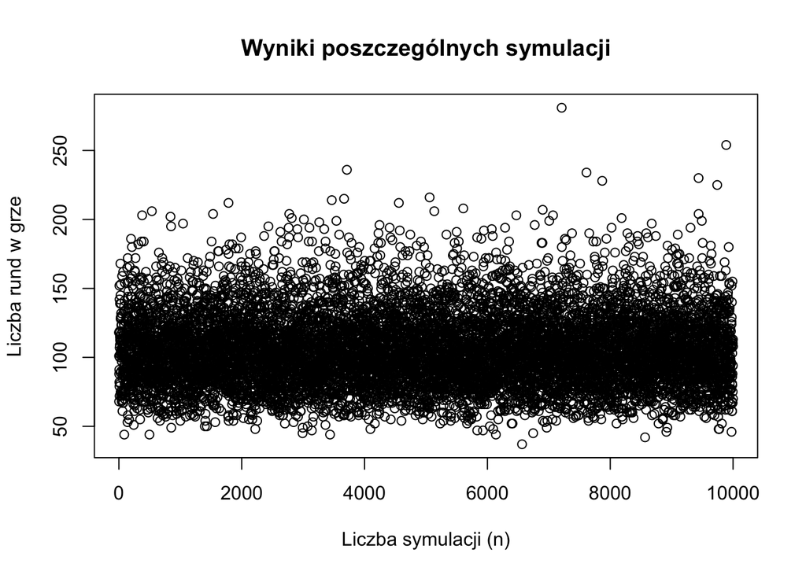

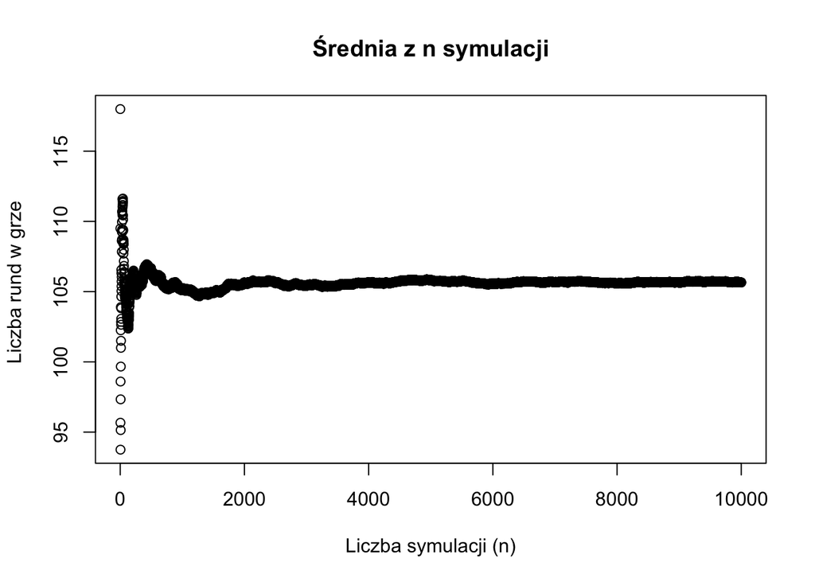

```r
f.statystyki(historia)
```